# Capítulo 5 - Residualização

## Revisando Métricas

Quais métricas otimizamos direta ou indiretamente?

[figure not shown]

### (MAX) Feature exposure (por era)

- Feature mais correlacionada com as predições $(fe\_max)$ gerada pelo modelo (por era)

$$fe\_max = \frac{\sum_{era=1}^{120} fe\_max_{era}}{120}$$

#### Relembrando Cap3 (Performance de uma feature)

[figure not shown]

#### Regularização

- Podemos controlar a exposição as features a partir do parâmetro de regularização ($\alpha$) que é encontrado no modelo **Ridge** e também nos modelos de árvore.
- Existem outras formas de regularização como o **Dropout** em Redes Neurais.

### Feature Neutral Mean (Neutralization/Residualization)

#### A residualização é uma aplicação do Teorema de Frisch-Waugh-Lovell (1933)

- O Teorema FWL fornece uma expressão fechada para obter um **subconjunto do vetor de coeficientes** de uma regressão múltipla (Greene 2003).
- Para dois conjuntos de variáveis, X1 e X2 o subconjunto de coeficientes ($b_2$) é obtido quando os resíduos da regressão de y em X1 são **regredidos no conjunto de resíduos** obtidos quando cada coluna de X2 é regredida em X1 (Greene 2003).

#### Regressão em 2 passos

1. Regressão de y em $X_1$: $M_{X1}y$ é o resíduo
2. Regressão de $X_2$ em $X_1$: $M_{X1}X_2$ é o resíduo
- Temos que:

$$M_{X1}y = M_{X1}X_2 \cdot \widehat{\beta_2} + \widehat{\mu}$$

- $M_{XI}y$ : Tudo de y que não foi explicado por $X_1$, mas pode ser explicado por $X_2$
- $M_{XI}X_2$ : Tudo de $X_2$ que não está sendo explicado por $X_1$
- O Teorema FWL prova que $\widehat{\beta_2}$ é igual a $b_2$

*Fonte: GREENE, W.H. Econometric Analysis. 5th ed. New York, NY, PearsonEducation, 2003*

### Aplicando ao nosso problema

- A Neutralização é um método de subtrair a contribuição de outro vetor numérico, enquanto mantém a **informação original**.
- Iremos neutralizar a propria previsao feita pelo modelo, por um modelo linear treinado sobre as previsões. O residuo resultante será **ortogonal a um OLS**.

$$score\_neutro = scores - prop \cdot exp \cdot (exp^{\dagger } \cdot scores)$$

- $exp^{\dagger }$ é a pseudo inversa de $exp$
- $ exp^{\dagger } \cdot scores = \beta$ (OLS)
- $prop$ entre $[0,1]$

#### Neutralizando a feature_strength34 em relação ao target

- Note que após a neutralização a feature se tornou **ortogonal ao target**
- Contudo possui **correlação próxima a 1**, a mesma feature antes da neutralização

```python
print("Corr fs_34 & target:             ", np.corrcoef(f1, df_training["target"])[0, 1])
print("Corr fs_34 100% neutr. & target: ", np.corrcoef(f1_nt, df_training["target"])[0, 1])
print("Corr fs_34 & fs_34 100% neutr.:  ", np.corrcoef(f1, f1_nt)[0, 1])
```

```
Corr fs_34 & target:              0.012310288017607295
Corr fs_34 100% neutr. & target:  1.7673754128672442e-08
Corr fs_34 & fs_34 100% neutr.:   0.999924225751144
```

#### A neutralização ajuda a mitigar o feature exposure, mas não é a mesma coisa

- Feature exposure é uma métrica que mede a **dissimilaridade** das correlações entre as features
- Feature Neutralization é uma operação que **remove a correlação** entre as features

#### Voltando as métricas de diagnóstico

- Feature neutral mean (neutralizado pelo **OLS** das predicoes)
- MMC Mean (neutralizado pelo **meta modelo** da numerai) (**proxy ex_preds**)

[figure not shown]

## Comparativo com e sem FN

- Atualizamos o modelos Medellin (lgbm_exp20) e o lgbm_slider20 de forma a considerar todas as eras

#### Sem FN (0 %)

```python
#print("Menor é melhor:", min_cols)
leaderboard_nr = df_metrics_cons_nr[df_metrics_cons_nr.Categoria.isin(["Performance", "Risk", "MMC"])].loc[:,models_nr[0:]]
leaderboard_nr.astype(float).style.apply(visualize.diagnostic_colors).apply(visualize.highlight_max, axis = 1)
```

| Metrica | ex_preds | nr__rio | nr__sao_paulo | lgbm_exp20 | lgbm_slider20 |
| --- | --- | --- | --- | --- | --- |
| Validation_Sharpe | 0.9757 | 0.9500 | 0.8757 | 0.9209 | 0.9678 |
| Validation_Mean | 0.0266 | 0.0264 | 0.0245 | 0.0244 | 0.0256 |
| Feat_neutral_mean | 0.0215 | 0.0206 | 0.0183 | 0.0182 | 0.0187 |
| Validation_SD | 0.0272 | 0.0278 | 0.0280 | 0.0265 | 0.0264 |
| Feat_exp_max | 0.2708 | 0.2601 | 0.2928 | 0.2642 | 0.2651 |
| Max_Drawdown | -0.0651 | -0.0867 | -0.0859 | -0.0995 | -0.0703 |
| corr_plus_mmc_sharpe | 0.9757 | 0.8973 | 0.7949 | 0.8359 | 0.9121 |
| val_mmc_mean | 0.0000 | 0.0017 | -0.0008 | 0.0010 | 0.0014 |
| corr_with_example_preds | 1.0000 | 0.9090 | 0.9632 | 0.8689 | 0.8943 |

#### Com FN (100 %)

- Os modelos são mais estáveis

```python
#print("Menor é melhor:", min_cols)
leaderboard_nr = df_metrics_cons_nr[df_metrics_cons_nr.Categoria.isin(["Performance", "Risk", "MMC"])].loc[:,models_nr]
leaderboard_nr.astype(float).style.apply(visualize.diagnostic_colors).apply(visualize.highlight_max, axis = 1)
```

| Metrica | ex_preds | nr__rio | nr__sao_paulo | lgbm_exp20 | lgbm_slider20 |
| --- | --- | --- | --- | --- | --- |
| Validation_Sharpe | 1.2648 | 1.2246 | 1.1207 | 1.0191 | 1.3628 |
| Validation_Mean | 0.0234 | 0.0226 | 0.0210 | 0.0195 | 0.0212 |
| Feat_neutral_mean | 0.0226 | 0.0217 | 0.0202 | 0.0186 | 0.0205 |
| Validation_SD | 0.0185 | 0.0185 | 0.0188 | 0.0191 | 0.0155 |
| Feat_exp_max | 0.0146 | 0.0108 | 0.0167 | 0.0089 | 0.0111 |
| Max_Drawdown | -0.0270 | -0.0352 | -0.0353 | -0.0462 | -0.0202 |
| corr_plus_mmc_sharpe | 1.2648 | 1.0213 | 0.8512 | 0.8088 | 1.0958 |
| val_mmc_mean | 0.0000 | 0.0070 | 0.0046 | 0.0053 | 0.0062 |
| corr_with_example_preds | 1.0000 | 0.5012 | 0.5621 | 0.4699 | 0.4876 |

#### Observe que o Validation Mean tende a convergir com o Feat Neutral Mean

## Testando Múltiplas proporções de FN

```python
model = 'nr__rio'
models_fn = ['ex_preds']+[model+str(fnv) for fnv in FN]

leaderboard_nr = df_metrics_cons_nr[df_metrics_cons_nr.Categoria.isin(["Performance", "Risk", "MMC"])].loc[:,models_fn[0:]]
leaderboard_nr.astype(float).style.apply(visualize.diagnostic_colors).apply(visualize.highlight_max, axis = 1)
```

| Metrica | ex_preds | nr__rio0 | nr__rio0.25 | nr__rio0.4 | nr__rio0.5 | nr__rio0.6 | nr__rio0.75 | nr__rio0.9 | nr__rio1.0 |
| --- | --- | --- | --- | --- | --- | --- | --- | --- | --- |
| Validation_Sharpe | 1.2648 | 0.9500 | 1.0188 | 1.0704 | 1.1126 | 1.1559 | 1.2141 | 1.2465 | 1.2246 |
| Validation_Mean | 0.0234 | 0.0264 | 0.0268 | 0.0269 | 0.0268 | 0.0264 | 0.0255 | 0.0240 | 0.0226 |
| Feat_neutral_mean | 0.0226 | 0.0206 | 0.0211 | 0.0213 | 0.0214 | 0.0214 | 0.0214 | 0.0215 | 0.0217 |
| Validation_SD | 0.0185 | 0.0278 | 0.0263 | 0.0251 | 0.0241 | 0.0229 | 0.0210 | 0.0192 | 0.0185 |
| Feat_exp_max | 0.0146 | 0.2601 | 0.2221 | 0.1910 | 0.1663 | 0.1380 | 0.0893 | 0.0371 | 0.0108 |
| Max_Drawdown | -0.0270 | -0.0867 | -0.0715 | -0.0584 | -0.0468 | -0.0410 | -0.0401 | -0.0373 | -0.0352 |
| corr_plus_mmc_sharpe | 1.2648 | 0.8973 | 0.9866 | 1.0429 | 1.0819 | 1.1109 | 1.1232 | 1.0847 | 1.0213 |
| val_mmc_mean | 0.0000 | 0.0017 | 0.0027 | 0.0034 | 0.0039 | 0.0045 | 0.0055 | 0.0064 | 0.0070 |
| corr_with_example_preds | 1.0000 | 0.9090 | 0.8792 | 0.8449 | 0.8124 | 0.7705 | 0.6879 | 0.5821 | 0.5012 |

## Customizando a neutralização

- No lugar do OLS, podemos usar na verdade **qualquer modelo**
- Modelos **não lineares** neutralizariam todo o sinal ortogonal encontrado pelo modelo original

#### SGD Regressor melhorou a validation_mean sem prejuízo as demais métricas

Para o SGD devemos aprender uma função linear onde: $f(x) = w^T x + b$

##### Para encontrar os parâmetros (w) do modelo, minimizamos o erro de treinamento:

$$E(w,b) = \frac{1}{n}\sum_{i=1}^{n} L(y_i, f(x_i)) + \alpha R(w)$$

[figure not shown]

### Customizando a neutralização (cont.)

- Modelos lineares com regularização como o ridge ou lasso **anularam** o efeito da neutralização
- Contudo, podemos **subtituir** parte do sinal linear neutralizado através de um modelo linear com regularização

##### Fomulação Original

$$score\_neutro = scores - [prop \cdot OLS] $$

#### Estratégias adotadas:

1. **NR__Rio**: $$[0.75\cdot SGD + 0.25 \cdot Ridge]$$
2. **NR__Sao_Paulo**: $$[0.9 \cdot SGD]$$
3. **NR__Medellin**: $$[0.75 \cdot OLS + 0.25 \cdot Ridge]$$

## Atualizando os Modelos com FN

- NR__Medellin passou para o *lgbm_slider20* com FN
- Atualizamos também o **baseline** com FN=100%

```python
#print("Menor é melhor:", min_cols)
leaderboard_nr = df_metrics_cons_nr[df_metrics_cons_nr.Categoria.isin(["Performance", "Risk", "MMC"])].loc[:,models_nr[0:]]
leaderboard_nr.astype(float).style.apply(visualize.diagnostic_colors).apply(visualize.highlight_max, axis = 1)
```

| Metrica | ex_preds | ex_FN100 | nr__rio | nr__sao_paulo | nr__medellin |
| --- | --- | --- | --- | --- | --- |
| Validation_Sharpe | 0.9757 | 1.2648 | 1.2787 | 1.2194 | 1.3584 |
| Validation_Mean | 0.0266 | 0.0234 | 0.0235 | 0.0238 | 0.0211 |
| Feat_neutral_mean | 0.0215 | 0.0226 | 0.0214 | 0.0196 | 0.0204 |
| Validation_SD | 0.0272 | 0.0185 | 0.0184 | 0.0195 | 0.0156 |
| Feat_exp_max | 0.2694 | 0.0146 | 0.0299 | 0.0614 | 0.0084 |
| Max_Drawdown | -0.0651 | -0.0270 | -0.0373 | -0.0417 | -0.0203 |
| corr_plus_mmc_sharpe | 0.9757 | 1.2648 | 1.0776 | 1.0050 | 1.0919 |
| val_mmc_mean | 0.0000 | 0.0000 | 0.0075 | 0.0041 | 0.0062 |
| corr_with_example_preds | 1.0000 | 1.0000 | 0.5091 | 0.6810 | 0.4869 |

```python
visualize.plot_era_scores(df_era_scores_nr, models_nr)
```

[interactive chart not shown]

# Modelo NR__Guadalajara

[figure not shown]

## Resumo do Modelo

- Explorar **ideias adicionais** a respeito de neutralização de variáveis (FN)
- Usaremos os **modelos pré neutralização** desenvolvidos até aqui como **base**
- Observar se houve melhoria quanto a **diversidade** das predições

### Neutralizando as features mais correlacionadas

- Pegamos os 3 modelos base (rio, sp, e medellin) pré FN
- Neutralizamos apenas as X% features mais correlacionadas (no treino)

#### O melhor modelo base foi o Rio, com 10% das features neutralizadas

```python
k_exposed
```

```
{'nr__rio': Index(['feature_charisma1', 'feature_charisma6', 'feature_charisma9',
        'feature_charisma10', 'feature_charisma11', 'feature_charisma18',
        'feature_charisma19', 'feature_charisma29', 'feature_charisma37',
        'feature_charisma40', 'feature_charisma46', 'feature_charisma54',
        'feature_charisma58', 'feature_charisma61', 'feature_charisma66',
        'feature_charisma69', 'feature_charisma71', 'feature_charisma75',
        'feature_charisma76', 'feature_charisma78', 'feature_charisma81',
        'feature_strength1', 'feature_strength4', 'feature_strength14',
        'feature_strength34', 'feature_dexterity4', 'feature_dexterity6',
        'feature_dexterity7', 'feature_dexterity11', 'feature_dexterity12',
        'feature_dexterity14'],
       dtype='object'),
 'nr__medellin': Index(['feature_intelligence2', 'feature_intelligence3', 'feature_charisma1',
        'feature_charisma9', 'feature_charisma11', 'feature_charisma19',
        'feature_charisma28', 'feature_charisma34', 'feature_charisma53',
        'feature_charisma55', 'feature_charisma58', 'feature_charisma69',
        'feature_strength1', 'feature_strength4', 'feature_strength10',
        'feature_strength36', 'feature_dexterity2', 'feature_dexterity3',
        'feature_dexterity4', 'feature_dexterity5', 'feature_dexterity6',
        'feature_dexterity7', 'feature_dexterity8', 'feature_dexterity10',
        'feature_dexterity11', 'feature_dexterity12', 'feature_dexterity13',
        'feature_dexterity14', 'feature_wisdom32', 'feature_wisdom36',
        'feature_wisdom42'],
       dtype='object')}
```

### NEUTRALIZAR POR GRUPO DE VARIÁVEIS

- A partir do modelo anterior decidimos testar neutralizar todas as combinações possíveis dos 6 grupos de features

```python
for key, value in feature_groups.items():
    print(value[-1])
```

```
feature_intelligence12
feature_wisdom46
feature_charisma86
feature_dexterity14
feature_strength38
feature_constitution114
```

#### O MELHOR MODELO BASE FOI O MEDELLIN NEUTRALIZANDO AS FEATURES DOS GRUPOS (Int., Dex., Str. e Const.)

### FN Threshold

- Neutralizamos as features com uma correlação acima de X% com o alvo (target)

#### O melhor modelo base foi o Medellin com um limite de exposição 5%

### Diagnóstico dos modelos

```python
#print("Menor é melhor:", min_cols) #by strategy 10%
leaderboard_nr = df_metrics_cons_nr[df_metrics_cons_nr.Categoria.isin(["Performance", "Risk", "MMC"]) ].loc[:,models_nr[:]]
leaderboard_nr.astype(float).style.apply(visualize.diagnostic_colors).apply(visualize.highlight_max, axis = 1)
```

| Metrica | ex_preds | ex_FN100 | nr__rio_top10 | nr__medellin_('intelligence', 'dexterity', 'strength', 'constitution') | nr__medellin_tr5 |
| --- | --- | --- | --- | --- | --- |
| Validation_Sharpe | 0.9757 | 1.2648 | 1.1393 | 1.3911 | 1.2504 |
| Validation_Mean | 0.0266 | 0.0234 | 0.0241 | 0.0270 | 0.0232 |
| Feat_neutral_mean | 0.0215 | 0.0226 | 0.0211 | 0.0195 | 0.0193 |
| Validation_SD | 0.0272 | 0.0185 | 0.0211 | 0.0194 | 0.0186 |
| Feat_exp_max | 0.2708 | 0.0146 | 0.1756 | 0.1909 | 0.0500 |
| Max_Drawdown | -0.0651 | -0.0270 | -0.0427 | -0.0178 | -0.0324 |
| corr_plus_mmc_sharpe | 0.9757 | 1.2648 | 0.9876 | 1.4151 | 1.0624 |
| val_mmc_mean | 0.0000 | 0.0000 | 0.0025 | 0.0064 | 0.0045 |
| corr_with_example_preds | 1.0000 | 1.0000 | 0.7809 | 0.6977 | 0.6448 |

```python
from src.visualization import visualize
leaderboard_nr = df_metrics_cons_nr[df_metrics_cons_nr.Categoria.isin([#"Performance",
                                                                       #"Risk",
                                                                       #"MMC",
                                                                       "MMC_FN",
                                                                       "Special"])].loc[:,models_nr[0:]]

leaderboard_nr.astype(float).style.apply(visualize.highlight_max_, axis = 1)
```

| Metrica | ex_preds | ex_FN100 | nr__rio_top10 | nr__medellin_('intelligence', 'dexterity', 'strength', 'constitution') | nr__medellin_tr5 |
| --- | --- | --- | --- | --- | --- |
| val_mmc_mean_FN | 0.0000 | 0.0000 | 0.0072 | 0.0092 | 0.0051 |
| corr_plus_mmc_sharpe_FN | 0.9757 | 1.2648 | 0.9445 | 1.2170 | 1.0619 |
| corr_with_ex_FN100 | 1.0000 | 1.0000 | 0.6263 | 0.6359 | 0.7042 |
| Adj_Sharpe | 0.5703 | 0.6828 | 0.6059 | 0.8551 | 0.6489 |
| Prob_Sharpe | 1.0000 | 1.0000 | 1.0000 | 1.0000 | 1.0000 |
| Deflated_Sharpe | 0.0000 | 0.0000 | 0.0000 | 0.0000 | 0.0000 |

### O Modelo Medelllin_idsc é o NR__Guadalajara

## Comparativo NR

```python
#print("Menor é melhor:", min_cols) #by strategy 10%
leaderboard_nr = df_metrics_cons_nr[df_metrics_cons_nr.Categoria.isin(["Performance", "Risk", "MMC"]) ].loc[:,models_nr[:]]
leaderboard_nr.astype(float).style.apply(visualize.diagnostic_colors).apply(visualize.highlight_max, axis = 1)
```

| Metrica | ex_preds | ex_FN100 | nr__rio | nr__sao_paulo | nr__medellin | nr__guadalajara |
| --- | --- | --- | --- | --- | --- | --- |
| Validation_Sharpe | 0.9757 | 1.2648 | 1.2787 | 1.2194 | 1.3584 | 1.3911 |
| Validation_Mean | 0.0266 | 0.0234 | 0.0235 | 0.0238 | 0.0211 | 0.0270 |
| Feat_neutral_mean | 0.0215 | 0.0226 | 0.0214 | 0.0196 | 0.0204 | 0.0195 |
| Validation_SD | 0.0272 | 0.0185 | 0.0184 | 0.0195 | 0.0156 | 0.0194 |
| Feat_exp_max | 0.2708 | 0.0146 | 0.0299 | 0.0614 | 0.0084 | 0.1909 |
| Max_Drawdown | -0.0651 | -0.0270 | -0.0373 | -0.0417 | -0.0203 | -0.0178 |
| corr_plus_mmc_sharpe | 0.9757 | 1.2648 | 1.0776 | 1.0050 | 1.0919 | 1.4151 |
| val_mmc_mean | 0.0000 | 0.0000 | 0.0075 | 0.0041 | 0.0062 | 0.0064 |
| corr_with_example_preds | 1.0000 | 1.0000 | 0.5103 | 0.6815 | 0.4871 | 0.6977 |

## Análise de diversidade

- Fizemos um teste de Friedman nos scores de todos os modelos de maneira conjunta
- Fizemos um Wilcoxon Signed-Rank Test nos scores de cada par de modelos
- Observamos a correlação de spearman entre as previsões de cada modelo

```python
stat.diversity_test(df_era_scores_nr, df_preds_nr)
```

```
Friedman Test
Testing: ['ex_preds', 'ex_FN100', 'nr__rio', 'nr__sao_paulo', 'nr__medellin', 'nr__guadalajara']
Statistics=8.918, p=0.112
Same distributions (fail to reject H0)


Testing: nr__medellin & nr__guadalajara
Statistics=108.000, p=0.031
Different distribution (reject H0)
Todas as Combinações de colunas testadas para Wilcoxon signed-rank test
```

#### A hipótese nula foi rejeitada apenas para o par Medellin e Guadalajara

- Neutralização no mesmo conjuto de variáveis não cria diversidade
- Seleção de variáveis pode gerar diversidade

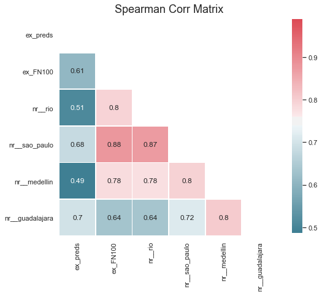

```python
stat.plot_corr_matrix(df_preds_nr)
```

```python
visualize.plot_era_scores(df_era_scores_nr, models_nr)
```

[interactive chart not shown]

# Resumo do modelo (relatorio final)

### Para o proximo modelo

- Diversidade